# Unknown map experiment - detection result delay

We are analyzing if offloading any of the three functionalities (i.e., SLAM, navigation and object recognition) has a statistically significant effect on the averagedetection result delay. Fist, install and load the required libraries:

```r
if (!require('tidyverse')) install.packages('tidyverse', dependencies = TRUE); library('tidyverse')
if (!require('ggpubr')) install.packages('ggpubr', dependencies = TRUE); library('ggpubr')
if (!require('rstatix')) install.packages('rstatix', dependencies = TRUE); library('rstatix')
if (!require('ggplot2')) install.packages('ggplot2', dependencies = TRUE); library('ggplot2')
if (!require('lmPerm')) install.packages('lmPerm', dependencies = TRUE); library('lmPerm')
if (!require('emmeans')) install.packages('emmeans', dependencies = TRUE); library('emmeans')
```

Next, load the experiment results from the csv file:

```r
data <- read.csv(file = '../../raw_data/unknown_map_experiment/run_table.csv')
data <- subset(data, select = c(X__run_id, slam_offloaded, navigation_offloaded, obj_recognition_offloaded, avg_detection_result_delay_ms))
data$slam_offloaded <- as.factor(data$slam_offloaded)
data$navigation_offloaded <- as.factor(data$navigation_offloaded)
data$obj_recognition_offloaded <- as.factor(data$obj_recognition_offloaded)
data$avg_detection_result_delay_ms <- as.numeric(data$avg_detection_result_delay_ms)
```

Mean and standard deviation of the average detection result delay for each treatment are displayed in the summary below:

```r
data %>%
  group_by(slam_offloaded, navigation_offloaded, obj_recognition_offloaded) %>%
  get_summary_stats(avg_detection_result_delay_ms, type = "mean_sd")
```

| slam_offloaded | navigation_offloaded | obj_recognition_offloaded | variable | n | mean | sd |
| --- | --- | --- | --- | --- | --- | --- |
| false | false | false | avg_detection_result_delay_ms | 10 | 0.954 | 0.042 |
| false | false | true | avg_detection_result_delay_ms | 10 | 2.755 | 0.302 |
| false | true | false | avg_detection_result_delay_ms | 10 | 0.948 | 0.030 |
| false | true | true | avg_detection_result_delay_ms | 10 | 2.966 | 0.341 |
| true | false | false | avg_detection_result_delay_ms | 10 | 0.853 | 0.018 |
| true | false | true | avg_detection_result_delay_ms | 10 | 2.845 | 0.174 |
| true | true | false | avg_detection_result_delay_ms | 10 | 0.862 | 0.029 |
| true | true | true | avg_detection_result_delay_ms | 10 | 3.030 | 0.674 |

# Three-Way ANOVA test

Since there are three independent variables in the experiment, we opt for three-way ANOVA test. First, we need to check if all assumptions for performing the test are met. The fist assumption of having independent observations is met inherently according to the way the experiment itself is conducted.

## No extreme outliers assumption

Next, we need to check if there are any extreme outliers:

```r
data %>%
  group_by(slam_offloaded, navigation_offloaded, obj_recognition_offloaded) %>%
  identify_outliers(avg_detection_result_delay_ms)
```

| slam_offloaded | navigation_offloaded | obj_recognition_offloaded | X__run_id | avg_detection_result_delay_ms | is.outlier | is.extreme |
| --- | --- | --- | --- | --- | --- | --- |
| false | false | true | run_26 | 3.191840 | TRUE | FALSE |
| false | false | true | run_77 | 2.002254 | TRUE | TRUE |
| true | false | true | run_33 | 2.486915 | TRUE | FALSE |
| true | true | true | run_58 | 4.640935 | TRUE | FALSE |

The results show that there are four outliers, in runs 26, 77, 33 and 58, respectfully, while run 77 represents an extreme outlier. We should remove the said run from the dataset, but we can also leave it if we believe that it will not have a significant effect on the obtained results. Let us make an alternative dataset with the extreme outliers being removed:

```r
data_without_outliers <- data
data_without_outliers <- data_without_outliers[!(data_without_outliers$X__run_id == 'run_77'),]
```

We proceed to check the next assumption - normality of the data.

## Normality assumption by analyzing the model residuals

The first way to check normality assumption is by analyzing the model residuals:

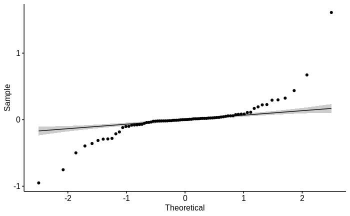

```r
model  <- lm(avg_detection_result_delay_ms ~ slam_offloaded*navigation_offloaded*obj_recognition_offloaded, data = data)
ggqqplot(residuals(model))
```

```r
shapiro_test(residuals(model)) %>%
  add_significance()
```

| variable | statistic | p.value | p.value.signif |
| --- | --- | --- | --- |
| residuals(model) | 0.7210698 | 4.955858e-11 | **** |

The p-value of $4.96 \cdot 10^{-11}$ shows that we can reject $H_0$, which states that the data is indeed normally distributed. We can conclude that the normally constraint is not satisfied. If we try with the dataset that does not contain outliers:

```r
model_without_outliers  <- lm(avg_detection_result_delay_ms ~ slam_offloaded*navigation_offloaded*obj_recognition_offloaded, data = data_without_outliers)
shapiro_test(residuals(model_without_outliers)) %>%
  add_significance()
```

| variable | statistic | p.value | p.value.signif |
| --- | --- | --- | --- |
| residuals(model_without_outliers) | 0.6927739 | 1.438894e-11 | **** |

we get very similar results that lead to the conclusion that normality of residuals is indeed not satisfied.

## Normality assumption by each group

The other way to check normality is by analyzing if samples for each possible treatment combination are normally distributed:

```r
data %>%
  group_by(slam_offloaded, navigation_offloaded, obj_recognition_offloaded) %>%
  shapiro_test(avg_detection_result_delay_ms) %>%
  add_significance()
```

| slam_offloaded | navigation_offloaded | obj_recognition_offloaded | variable | statistic | p | p.signif |
| --- | --- | --- | --- | --- | --- | --- |
| false | false | false | avg_detection_result_delay_ms | 0.9729617 | 0.91686476 | ns |
| false | false | true | avg_detection_result_delay_ms | 0.7921510 | 0.01163807 | * |
| false | true | false | avg_detection_result_delay_ms | 0.9662540 | 0.85410889 | ns |
| false | true | true | avg_detection_result_delay_ms | 0.9159400 | 0.32433239 | ns |
| true | false | false | avg_detection_result_delay_ms | 0.9494144 | 0.66157671 | ns |
| true | false | true | avg_detection_result_delay_ms | 0.9443000 | 0.60177312 | ns |
| true | true | false | avg_detection_result_delay_ms | 0.9312882 | 0.46068170 | ns |
| true | true | true | avg_detection_result_delay_ms | 0.8771743 | 0.12107771 | ns |

Shapiro-Wilk test per each group yields p-value higher than `0.05` for all group except one, when SLAM and navigation are not offloaded but object recognition is. If we execute the test on the dataset without extreme outliers:

```r
data_without_outliers %>%
  group_by(slam_offloaded, navigation_offloaded, obj_recognition_offloaded) %>%
  shapiro_test(avg_detection_result_delay_ms) %>%
  add_significance()
```

| slam_offloaded | navigation_offloaded | obj_recognition_offloaded | variable | statistic | p | p.signif |
| --- | --- | --- | --- | --- | --- | --- |
| false | false | false | avg_detection_result_delay_ms | 0.9729617 | 0.91686476 | ns |
| false | false | true | avg_detection_result_delay_ms | 0.8336344 | 0.04904312 | * |
| false | true | false | avg_detection_result_delay_ms | 0.9662540 | 0.85410889 | ns |
| false | true | true | avg_detection_result_delay_ms | 0.9159400 | 0.32433239 | ns |
| true | false | false | avg_detection_result_delay_ms | 0.9494144 | 0.66157671 | ns |
| true | false | true | avg_detection_result_delay_ms | 0.9443000 | 0.60177312 | ns |
| true | true | false | avg_detection_result_delay_ms | 0.9312882 | 0.46068170 | ns |
| true | true | true | avg_detection_result_delay_ms | 0.8771743 | 0.12107771 | ns |

the conclusions remain the same. The QQ-plots per group are depicted below, where most of the data points seem to be aligned with the reference line:

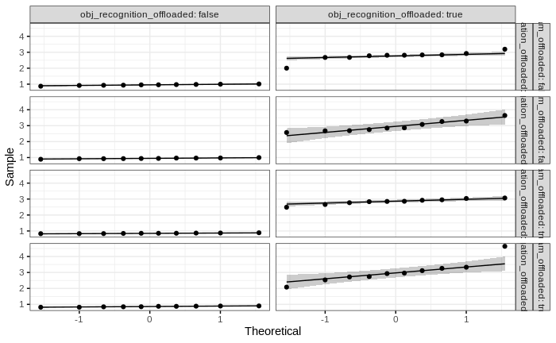

```r
ggqqplot(data, "avg_detection_result_delay_ms", ggtheme = theme_bw()) +
  facet_grid(slam_offloaded + navigation_offloaded ~ obj_recognition_offloaded, labeller = "label_both")
```

## Homogeneity of variance assumption

Homogeneity of variance assumption can be checked via Levene’s test:

```r
data %>%
  levene_test(avg_detection_result_delay_ms ~ slam_offloaded*navigation_offloaded*obj_recognition_offloaded) %>%
  add_significance()
```

| df1 | df2 | statistic | p | p.signif |
| --- | --- | --- | --- | --- |
| 7 | 72 | 4.500932 | 0.0003326435 | *** |

Since the p-value is lower than `0.05`, the result of the Levene’s test is statistically significant, hence the null hypothesis stating that homogeneity of variance holds is rejected. If we compute the Levene’s test on dataset without extreme outliers:

```r
data_without_outliers %>%
  levene_test(avg_detection_result_delay_ms ~ slam_offloaded*navigation_offloaded*obj_recognition_offloaded) %>%
  add_significance()
```

| df1 | df2 | statistic | p | p.signif |
| --- | --- | --- | --- | --- |
| 7 | 71 | 5.109023 | 9.747586e-05 | **** |

we can draw the same conclusion - homogeneity of variance assumption is not satisfied hence we cannot apply three-way ANOVA. With the disputable normality constraint and no homogeneity of variance, we need to turn to non-parametric alternative of three-way ANOVA - permutation test.

# Permutation test

Execution of permutation test yields the following result:

```r
summary(aovp(avg_detection_result_delay_ms ~ slam_offloaded*navigation_offloaded*obj_recognition_offloaded, data = data, perm="Prob", maxIter=500000, nCycle=100, Ca=0.001))
```

```
[1] "Settings:  unique SS "
Component 1 :
                                                              Df R Sum Sq R Mean Sq   Iter Pr(Prob)
slam_offloaded                                                 1    0.001     0.001 111169   0.9000
navigation_offloaded                                           1    0.200     0.200 500000   0.1317
slam_offloaded:navigation_offloaded                            1    0.000     0.000  32046   0.9690
obj_recognition_offloaded                                      1   79.565    79.565 500000   <2e-16 ***
slam_offloaded:obj_recognition_offloaded                       1    0.146     0.146 500000   0.1971
navigation_offloaded:obj_recognition_offloaded                 1    0.192     0.192 500000   0.1412
slam_offloaded:navigation_offloaded:obj_recognition_offloaded  1    0.002     0.002 132831   0.8827
Residuals                                                     72    6.261     0.087
---
Signif. codes:  0 ‘***’ 0.001 ‘**’ 0.01 ‘*’ 0.05 ‘.’ 0.1 ‘ ’ 1
```

Test results show that the main effect is significant only when object recognition is offloaded and there are no significant three-way or two-way interactions. If we compare these results with three-way ANOVA results, that is considered as *robust* when sample sizes are equal for each group, which is indeed the case in this experiment:

```r
data %>%
  anova_test(avg_detection_result_delay_ms ~ slam_offloaded*navigation_offloaded*obj_recognition_offloaded)
```

```
Coefficient covariances computed by hccm()
```

```
ANOVA Table (type II tests)

                                                         Effect DFn DFd       F        p p<.05      ges
1                                                slam_offloaded   1  72   0.015 9.02e-01       2.12e-04
2                                          navigation_offloaded   1  72   2.301 1.34e-01       3.10e-02
3                                     obj_recognition_offloaded   1  72 914.966 1.14e-42     * 9.27e-01
4                           slam_offloaded:navigation_offloaded   1  72   0.002 9.67e-01       2.38e-05
5                      slam_offloaded:obj_recognition_offloaded   1  72   1.684 1.99e-01       2.30e-02
6                navigation_offloaded:obj_recognition_offloaded   1  72   2.213 1.41e-01       3.00e-02
7 slam_offloaded:navigation_offloaded:obj_recognition_offloaded   1  72   0.024 8.78e-01       3.30e-04
```

we see that the obtained p-values and conclusions are very similar to those drawn from the permutation test. The eta-squared effect sizes are:

```r
res.aov <- aov(avg_detection_result_delay_ms ~ slam_offloaded*navigation_offloaded*obj_recognition_offloaded, data = data)
eta_squared(res.aov)
```

```
                                               slam_offloaded                                          navigation_offloaded
                                                 1.537510e-05                                                  2.316620e-03
                                    obj_recognition_offloaded                           slam_offloaded:navigation_offloaded
                                                 9.212261e-01                                                  1.728883e-06
                     slam_offloaded:obj_recognition_offloaded                navigation_offloaded:obj_recognition_offloaded
                                                 1.695606e-03                                                  2.228002e-03
slam_offloaded:navigation_offloaded:obj_recognition_offloaded
                                                 2.392136e-05
```

# Results

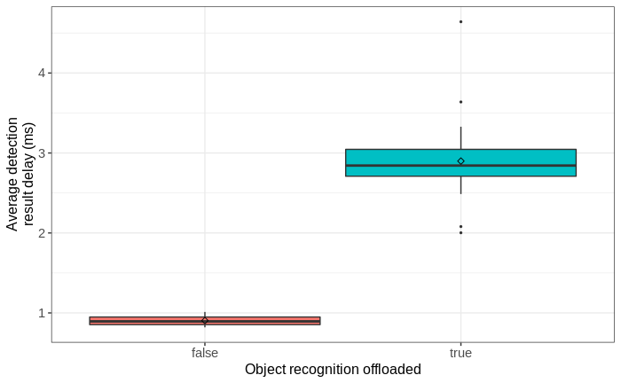

```r
#pdf(file = "../../figures/unknown_map_experiment/detection-result-delay-1.pdf")

ggplot(data, aes(x = obj_recognition_offloaded, y = avg_detection_result_delay_ms, fill = obj_recognition_offloaded)) +
  theme_bw() +
  geom_boxplot(width = 0.9, outlier.size = 0.5) +
  stat_summary(fun = mean, color = 'black', geom = 'point', shape = 5) +
  labs(x = "Object recognition offloaded", y = "Average detection\nresult delay (ms)") +
  theme(legend.position = "none") +
  theme(
    axis.title.x = element_text(size = 12, family = 'sans'),
    axis.title.y = element_text(size = 12, family = 'sans'),
    axis.text.x = element_text(size = 11, family = 'sans'),
    axis.text.y = element_text(size = 11, family = 'sans')
  )
```

```r
#dev.off()
```

We can indeed see from the boxplot above that the result delay is much higher when object recognition is offloaded.